# Assignment2_FNN

Train two different FFN models using Keras:

• A model to learn the Sine function in the range (-𝜋, 𝜋) and the second to learn another arbitrary but non-trivial function of your choice.

• Plot the learned mapping for a given range (𝜋, 2𝜋) and compare it with the Sine wave for the first model and a suitable range for the second model.

• Summarize the model architectures for both models.

• Neural networks are known to be “Universal Function Approximators”. Would you agree with the statement based on this experiment?

# CASE 1: Generate data for the Sine function in the range (-2π, 2π)

```python
import numpy as np
import matplotlib.pyplot as plt
from keras.models import Sequential
from keras.layers import Dense, Dropout
from keras.optimizers import Adam
from sklearn.preprocessing import StandardScaler

# Use inline backend for Jupyter
%matplotlib inline

np.random.seed(7)



# -----------------------------------------------------------------------------
# Generate data for the Sine function in the range (-2π, 2π)
# -----------------------------------------------------------------------------

T = 8000
X_sine_train = np.linspace(-2*np.pi, 2*np.pi, T).reshape(-1, 1)
Y_sine_train = np.sin(X_sine_train)

# Normalize the data for sine function
scaler_sine = StandardScaler()
X_sine_train_scaled = scaler_sine.fit_transform(X_sine_train)



# -----------------------------------------------------------------------------
# Generate data for the Exponential Sine function in the range (0, 4π)
# -----------------------------------------------------------------------------
X_exp_sine_train = np.linspace(0, 4*np.pi, T).reshape(-1, 1)
Y_exp_sine_train = np.exp(0.2 * X_exp_sine_train) * np.sin(X_exp_sine_train)

# Normalize the data for exponential sine function
scaler_exp_sine = StandardScaler()
X_exp_sine_train_scaled = scaler_exp_sine.fit_transform(X_exp_sine_train)
```

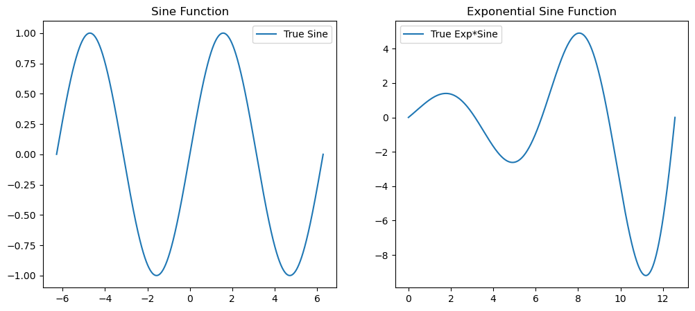

```python
plt.figure(figsize=(12, 5))

# Plot Sine function
plt.subplot(1, 2, 1)
plt.plot(X_sine_train, Y_sine_train, label='True Sine')
plt.title('Sine Function')
plt.legend()

# Plot Exponential Sine function
plt.subplot(1, 2, 2)
plt.plot(X_exp_sine_train, Y_exp_sine_train, label='True Exp*Sine')
plt.title('Exponential Sine Function')
plt.legend()

plt.show()
```

```python
# -----------------------------------------------------------------------------
# Build the Keras models
# -----------------------------------------------------------------------------
input_dim = 1



# Model for Sine function
sine_model = Sequential()
sine_model.add(Dense(10, input_dim=input_dim, activation='tanh'))
sine_model.add(Dense(90, activation='tanh'))
for _ in range(8):
    sine_model.add(Dense(10, activation='tanh'))
sine_model.add(Dense(1, activation=None))  # No activation on the output layer



# Model for Exponential Sine function
exp_sine_model = Sequential()
exp_sine_model.add(Dense(64, input_dim=input_dim, activation='relu'))
exp_sine_model.add(Dense(128, activation='relu'))
exp_sine_model.add(Dense(128, activation='relu'))
exp_sine_model.add(Dropout(0.2))  # Add dropout for regularization
exp_sine_model.add(Dense(64, activation='relu'))
exp_sine_model.add(Dense(64, activation='relu'))
exp_sine_model.add(Dense(32, activation='relu'))
exp_sine_model.add(Dropout(0.2))  # Add dropout for regularization
exp_sine_model.add(Dense(16, activation='relu'))
exp_sine_model.add(Dense(1, activation=None))  # No activation on the output layer
```

```python
# -----------------------------------------------------------------------------
# Compile and fit the models
# -----------------------------------------------------------------------------

sine_model.compile(loss='mean_squared_error', optimizer=Adam(learning_rate=0.001), metrics=['accuracy'])
exp_sine_model.compile(loss='mean_squared_error', optimizer=Adam(learning_rate=0.001), metrics=['accuracy'])

sine_model.fit(X_sine_train_scaled, Y_sine_train, epochs=400, batch_size=32, verbose=0)
exp_sine_model.fit(X_exp_sine_train_scaled, Y_exp_sine_train, epochs=400, batch_size=32, verbose=0)
```

```
<keras.src.callbacks.history.History at 0x1c9164111d0>
```

```python
# -----------------------------------------------------------------------------
# Generate evaluation data in the range (π, 2π) for both functions
# -----------------------------------------------------------------------------

X_eval = np.linspace(1*np.pi, 2*np.pi, T).reshape(-1, 1)

Y_sine_eval = np.sin(X_eval)
Y_exp_sine_eval = np.exp(0.2 * X_eval) * np.sin(X_eval)

X_eval_scaled_sine = scaler_sine.transform(X_eval)
X_eval_scaled_exp_sine = scaler_exp_sine.transform(X_eval)

# Predict using the models
Y_sine_pred = sine_model.predict(X_eval_scaled_sine)
Y_exp_sine_pred = exp_sine_model.predict(X_eval_scaled_exp_sine)
```

```
250/250 ━━━━━━━━━━━━━━━━━━━━ 0s 669us/step
250/250 ━━━━━━━━━━━━━━━━━━━━ 0s 757us/step
```

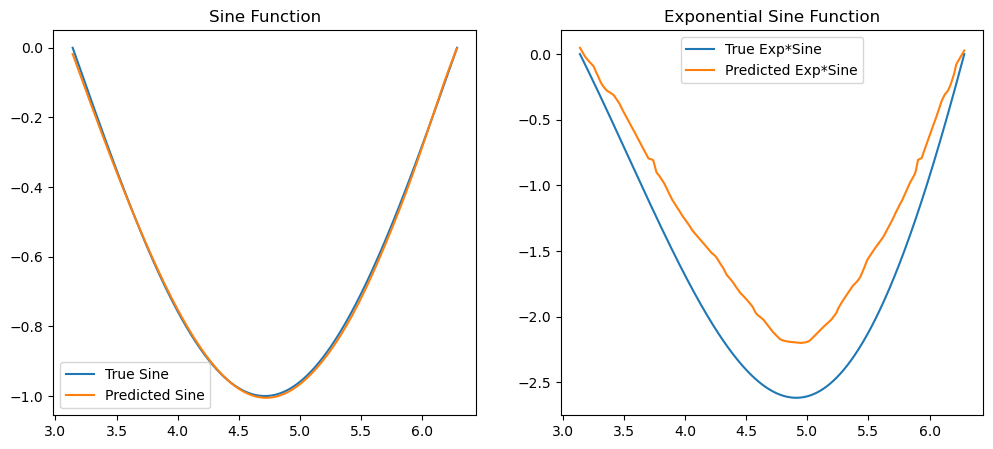

```python
# -----------------------------------------------------------------------------
# Compare predictions vs ground truth
# -----------------------------------------------------------------------------
plt.figure(figsize=(12, 5))

# Plot Sine function predictions
plt.subplot(1, 2, 1)
plt.plot(X_eval, Y_sine_eval, label='True Sine')
plt.plot(X_eval, Y_sine_pred, label='Predicted Sine')
plt.title('Sine Function')
plt.legend()

# Plot Exponential Sine function predictions
plt.subplot(1, 2, 2)
plt.plot(X_eval, Y_exp_sine_eval, label='True Exp*Sine')
plt.plot(X_eval, Y_exp_sine_pred, label='Predicted Exp*Sine')
plt.title('Exponential Sine Function')
plt.legend()

plt.show()
```

```python
# -----------------------------------------------------------------------------
# Summarize the models
# -----------------------------------------------------------------------------
print("Sine Model Summary:")
sine_model.summary()

print("\nExponential Sine Model Summary:")
exp_sine_model.summary()
```

```
Sine Model Summary:
```

```
Model: "sequential"
```

```
┏━━━━━━━━━━━━━━━━━━━━━━━━━━━━━━━━━━━━━━┳━━━━━━━━━━━━━━━━━━━━━━━━━━━━━┳━━━━━━━━━━━━━━━━━┓
┃ Layer (type)                         ┃ Output Shape                ┃         Param # ┃
┡━━━━━━━━━━━━━━━━━━━━━━━━━━━━━━━━━━━━━━╇━━━━━━━━━━━━━━━━━━━━━━━━━━━━━╇━━━━━━━━━━━━━━━━━┩
│ dense (Dense)                        │ (None, 10)                  │              20 │
├──────────────────────────────────────┼─────────────────────────────┼─────────────────┤
│ dense_1 (Dense)                      │ (None, 90)                  │             990 │
├──────────────────────────────────────┼─────────────────────────────┼─────────────────┤
│ dense_2 (Dense)                      │ (None, 10)                  │             910 │
├──────────────────────────────────────┼─────────────────────────────┼─────────────────┤
│ dense_3 (Dense)                      │ (None, 10)                  │             110 │
├──────────────────────────────────────┼─────────────────────────────┼─────────────────┤
│ dense_4 (Dense)                      │ (None, 10)                  │             110 │
├──────────────────────────────────────┼─────────────────────────────┼─────────────────┤
│ dense_5 (Dense)                      │ (None, 10)                  │             110 │
├──────────────────────────────────────┼─────────────────────────────┼─────────────────┤
│ dense_6 (Dense)                      │ (None, 10)                  │             110 │
├──────────────────────────────────────┼─────────────────────────────┼─────────────────┤
│ dense_7 (Dense)                      │ (None, 10)                  │             110 │
├──────────────────────────────────────┼─────────────────────────────┼─────────────────┤
│ dense_8 (Dense)                      │ (None, 10)                  │             110 │
├──────────────────────────────────────┼─────────────────────────────┼─────────────────┤
│ dense_9 (Dense)                      │ (None, 10)                  │             110 │
├──────────────────────────────────────┼─────────────────────────────┼─────────────────┤
│ dense_10 (Dense)                     │ (None, 1)                   │              11 │
└──────────────────────────────────────┴─────────────────────────────┴─────────────────┘
```

```
 Total params: 8,105 (31.66 KB)
```

```
 Trainable params: 2,701 (10.55 KB)
```

```
 Non-trainable params: 0 (0.00 B)
```

```
 Optimizer params: 5,404 (21.11 KB)
```

```
Exponential Sine Model Summary:
```

```
Model: "sequential_1"
```

```
┏━━━━━━━━━━━━━━━━━━━━━━━━━━━━━━━━━━━━━━┳━━━━━━━━━━━━━━━━━━━━━━━━━━━━━┳━━━━━━━━━━━━━━━━━┓
┃ Layer (type)                         ┃ Output Shape                ┃         Param # ┃
┡━━━━━━━━━━━━━━━━━━━━━━━━━━━━━━━━━━━━━━╇━━━━━━━━━━━━━━━━━━━━━━━━━━━━━╇━━━━━━━━━━━━━━━━━┩
│ dense_11 (Dense)                     │ (None, 64)                  │             128 │
├──────────────────────────────────────┼─────────────────────────────┼─────────────────┤
│ dense_12 (Dense)                     │ (None, 128)                 │           8,320 │
├──────────────────────────────────────┼─────────────────────────────┼─────────────────┤
│ dense_13 (Dense)                     │ (None, 128)                 │          16,512 │
├──────────────────────────────────────┼─────────────────────────────┼─────────────────┤
│ dropout (Dropout)                    │ (None, 128)                 │               0 │
├──────────────────────────────────────┼─────────────────────────────┼─────────────────┤
│ dense_14 (Dense)                     │ (None, 64)                  │           8,256 │
├──────────────────────────────────────┼─────────────────────────────┼─────────────────┤
│ dense_15 (Dense)                     │ (None, 64)                  │           4,160 │
├──────────────────────────────────────┼─────────────────────────────┼─────────────────┤
│ dense_16 (Dense)                     │ (None, 32)                  │           2,080 │
├──────────────────────────────────────┼─────────────────────────────┼─────────────────┤
│ dropout_1 (Dropout)                  │ (None, 32)                  │               0 │
├──────────────────────────────────────┼─────────────────────────────┼─────────────────┤
│ dense_17 (Dense)                     │ (None, 16)                  │             528 │
├──────────────────────────────────────┼─────────────────────────────┼─────────────────┤
│ dense_18 (Dense)                     │ (None, 1)                   │              17 │
└──────────────────────────────────────┴─────────────────────────────┴─────────────────┘
```

```
 Total params: 120,005 (468.77 KB)
```

```
 Trainable params: 40,001 (156.25 KB)
```

```
 Non-trainable params: 0 (0.00 B)
```

```
 Optimizer params: 80,004 (312.52 KB)
```

# CASE 2: Generate data for the Sine function in the range (-π, π), Exponential Sine function in the range (-6π, π). Evaluation data in the range (π, 2π) for both functions.

```python
import numpy as np
import matplotlib.pyplot as plt
from keras.models import Sequential
from keras.layers import Dense, Dropout
from keras.optimizers import Adam
from sklearn.preprocessing import StandardScaler

# Use inline backend for Jupyter
%matplotlib inline

np.random.seed(7)



# -----------------------------------------------------------------------------
# Generate data for the Sine function in the range (-π, π)
# -----------------------------------------------------------------------------

T = 8000
X_sine_train = np.linspace(-1*np.pi, 1*np.pi, T).reshape(-1, 1)
Y_sine_train = np.sin(X_sine_train)

# Normalize the data for sine function
scaler_sine = StandardScaler()
X_sine_train_scaled = scaler_sine.fit_transform(X_sine_train)



# -----------------------------------------------------------------------------
# Generate data for the Exponential Sine function in the range (-6π, π)
# -----------------------------------------------------------------------------
X_exp_sine_train = np.linspace(-6*np.pi, 1*np.pi, T).reshape(-1, 1)
Y_exp_sine_train = np.exp(0.2 * X_exp_sine_train) * np.sin(X_exp_sine_train)

# Normalize the data for exponential sine function
scaler_exp_sine = StandardScaler()
X_exp_sine_train_scaled = scaler_exp_sine.fit_transform(X_exp_sine_train)
```

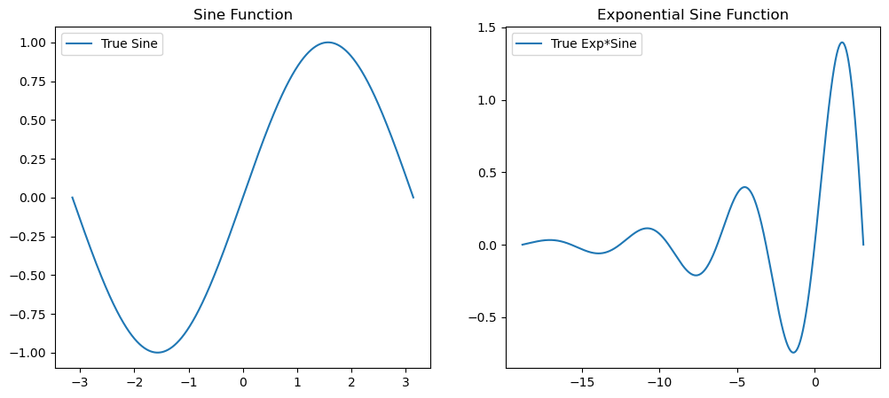

```python
plt.figure(figsize=(12, 5))

# Plot Sine function
plt.subplot(1, 2, 1)
plt.plot(X_sine_train, Y_sine_train, label='True Sine')
plt.title('Sine Function')
plt.legend()

# Plot Exponential Sine function
plt.subplot(1, 2, 2)
plt.plot(X_exp_sine_train, Y_exp_sine_train, label='True Exp*Sine')
plt.title('Exponential Sine Function')
plt.legend()

plt.show()
```

```python
# -----------------------------------------------------------------------------
# Build the Keras models
# -----------------------------------------------------------------------------
input_dim = 1



# Model for Sine function
sine_model = Sequential()
sine_model.add(Dense(10, input_dim=input_dim, activation='tanh'))
sine_model.add(Dense(90, activation='tanh'))
for _ in range(8):
    sine_model.add(Dense(10, activation='tanh'))
sine_model.add(Dense(1, activation=None))  # No activation on the output layer



# Model for Exponential Sine function
exp_sine_model = Sequential()
exp_sine_model.add(Dense(64, input_dim=input_dim, activation='relu'))
exp_sine_model.add(Dense(128, activation='relu'))
exp_sine_model.add(Dense(128, activation='relu'))
exp_sine_model.add(Dropout(0.2))  # Add dropout for regularization
exp_sine_model.add(Dense(64, activation='relu'))
exp_sine_model.add(Dense(64, activation='relu'))
exp_sine_model.add(Dense(32, activation='relu'))
exp_sine_model.add(Dropout(0.2))  # Add dropout for regularization
exp_sine_model.add(Dense(16, activation='relu'))
exp_sine_model.add(Dense(1, activation=None))  # No activation on the output layer
```

```python
# -----------------------------------------------------------------------------
# Compile and fit the models
# -----------------------------------------------------------------------------

sine_model.compile(loss='mean_squared_error', optimizer=Adam(learning_rate=0.001), metrics=['accuracy'])
exp_sine_model.compile(loss='mean_squared_error', optimizer=Adam(learning_rate=0.001), metrics=['accuracy'])

sine_model.fit(X_sine_train_scaled, Y_sine_train, epochs=400, batch_size=32, verbose=0)
exp_sine_model.fit(X_exp_sine_train_scaled, Y_exp_sine_train, epochs=400, batch_size=32, verbose=0)
```

```
<keras.src.callbacks.history.History at 0x1c91ff4a850>
```

```python
# -----------------------------------------------------------------------------
# Generate evaluation data in the range (π, 2π) for both functions
# -----------------------------------------------------------------------------

X_eval = np.linspace(1*np.pi, 2*np.pi, T).reshape(-1, 1)

Y_sine_eval = np.sin(X_eval)
Y_exp_sine_eval = np.exp(0.2 * X_eval) * np.sin(X_eval)

X_eval_scaled_sine = scaler_sine.transform(X_eval)
X_eval_scaled_exp_sine = scaler_exp_sine.transform(X_eval)

# Predict using the models
Y_sine_pred = sine_model.predict(X_eval_scaled_sine)
Y_exp_sine_pred = exp_sine_model.predict(X_eval_scaled_exp_sine)
```

```
250/250 ━━━━━━━━━━━━━━━━━━━━ 0s 749us/step
250/250 ━━━━━━━━━━━━━━━━━━━━ 0s 657us/step
```

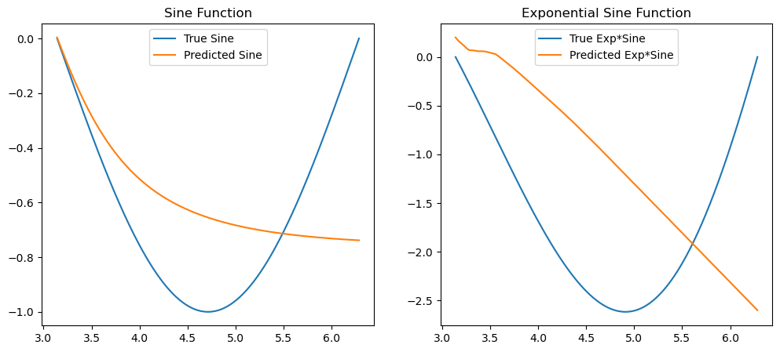

```python
# -----------------------------------------------------------------------------
# Compare predictions vs ground truth
# -----------------------------------------------------------------------------
plt.figure(figsize=(12, 5))

# Plot Sine function predictions
plt.subplot(1, 2, 1)
plt.plot(X_eval, Y_sine_eval, label='True Sine')
plt.plot(X_eval, Y_sine_pred, label='Predicted Sine')
plt.title('Sine Function')
plt.legend()

# Plot Exponential Sine function predictions
plt.subplot(1, 2, 2)
plt.plot(X_eval, Y_exp_sine_eval, label='True Exp*Sine')
plt.plot(X_eval, Y_exp_sine_pred, label='Predicted Exp*Sine')
plt.title('Exponential Sine Function')
plt.legend()

plt.show()
```

# Neural networks are known as "Universal Function Approximators" because, given sufficient capacity and appropriate training, they can approximate any continuous function to any desired degree of accuracy.

# In this experiment - CASE 1:

Thus, based on these results, it seems that that neural networks, given sufficient data, capacity, and training, are indeed universal function approximators. The performance seen here supports the theoretical claim, although practical considerations such as model architecture and training process play a significant role in achieving the desired approximation.

# In this experiment - CASE 2:

FFN struggles with cyclical patterns. However LSTMs are designed for periodic behaviors. Better results shown with LSTM below.

# Now try LSTM

```
124/124 ━━━━━━━━━━━━━━━━━━━━ 7s 39ms/step - loss: 0.0491
124/124 ━━━━━━━━━━━━━━━━━━━━ 5s 38ms/step - loss: 2.1861e-05
124/124 ━━━━━━━━━━━━━━━━━━━━ 5s 41ms/step - loss: 2.0724e-05
124/124 ━━━━━━━━━━━━━━━━━━━━ 5s 42ms/step - loss: 1.9558e-05
124/124 ━━━━━━━━━━━━━━━━━━━━ 5s 40ms/step - loss: 1.8319e-05
124/124 ━━━━━━━━━━━━━━━━━━━━ 5s 39ms/step - loss: 1.6526e-05
124/124 ━━━━━━━━━━━━━━━━━━━━ 5s 38ms/step - loss: 1.5501e-05
124/124 ━━━━━━━━━━━━━━━━━━━━ 5s 38ms/step - loss: 1.4180e-05
124/124 ━━━━━━━━━━━━━━━━━━━━ 5s 38ms/step - loss: 1.2728e-05
124/124 ━━━━━━━━━━━━━━━━━━━━ 5s 39ms/step - loss: 1.1647e-05
124/124 ━━━━━━━━━━━━━━━━━━━━ 5s 40ms/step - loss: 1.0591e-05
124/124 ━━━━━━━━━━━━━━━━━━━━ 5s 39ms/step - loss: 1.0065e-05
124/124 ━━━━━━━━━━━━━━━━━━━━ 5s 38ms/step - loss: 8.9958e-06
124/124 ━━━━━━━━━━━━━━━━━━━━ 5s 38ms/step - loss: 8.0104e-06
124/124 ━━━━━━━━━━━━━━━━━━━━ 5s 38ms/step - loss: 7.0065e-06
124/124 ━━━━━━━━━━━━━━━━━━━━ 5s 39ms/step - loss: 6.6863e-06
124/124 ━━━━━━━━━━━━━━━━━━━━ 5s 38ms/step - loss: 7.0945e-06
124/124 ━━━━━━━━━━━━━━━━━━━━ 5s 37ms/step - loss: 5.9349e-06
124/124 ━━━━━━━━━━━━━━━━━━━━ 5s 36ms/step - loss: 6.3739e-06
124/124 ━━━━━━━━━━━━━━━━━━━━ 5s 38ms/step - loss: 4.7101e-06
124/124 ━━━━━━━━━━━━━━━━━━━━ 6s 36ms/step - loss: 0.0255
124/124 ━━━━━━━━━━━━━━━━━━━━ 5s 38ms/step - loss: 3.9897e-05
124/124 ━━━━━━━━━━━━━━━━━━━━ 5s 37ms/step - loss: 3.6143e-05
124/124 ━━━━━━━━━━━━━━━━━━━━ 5s 41ms/step - loss: 3.3883e-05
124/124 ━━━━━━━━━━━━━━━━━━━━ 5s 38ms/step - loss: 3.1487e-05
124/124 ━━━━━━━━━━━━━━━━━━━━ 5s 38ms/step - loss: 3.0899e-05
124/124 ━━━━━━━━━━━━━━━━━━━━ 5s 37ms/step - loss: 2.7522e-05
124/124 ━━━━━━━━━━━━━━━━━━━━ 5s 39ms/step - loss: 2.5096e-05
124/124 ━━━━━━━━━━━━━━━━━━━━ 5s 38ms/step - loss: 2.6100e-05
124/124 ━━━━━━━━━━━━━━━━━━━━ 5s 38ms/step - loss: 2.3623e-05
124/124 ━━━━━━━━━━━━━━━━━━━━ 5s 38ms/step - loss: 1.8665e-05
124/124 ━━━━━━━━━━━━━━━━━━━━ 5s 38ms/step - loss: 1.7252e-05
124/124 ━━━━━━━━━━━━━━━━━━━━ 5s 38ms/step - loss: 1.4411e-05
124/124 ━━━━━━━━━━━━━━━━━━━━ 5s 39ms/step - loss: 1.1603e-05
124/124 ━━━━━━━━━━━━━━━━━━━━ 5s 38ms/step - loss: 1.0890e-05
124/124 ━━━━━━━━━━━━━━━━━━━━ 5s 40ms/step - loss: 1.8767e-05
124/124 ━━━━━━━━━━━━━━━━━━━━ 5s 41ms/step - loss: 5.0772e-06
124/124 ━━━━━━━━━━━━━━━━━━━━ 5s 41ms/step - loss: 5.8799e-06
124/124 ━━━━━━━━━━━━━━━━━━━━ 5s 39ms/step - loss: 3.0284e-06
124/124 ━━━━━━━━━━━━━━━━━━━━ 5s 40ms/step - loss: 8.3904e-06
247/247 ━━━━━━━━━━━━━━━━━━━━ 3s 11ms/step
247/247 ━━━━━━━━━━━━━━━━━━━━ 3s 11ms/step
```

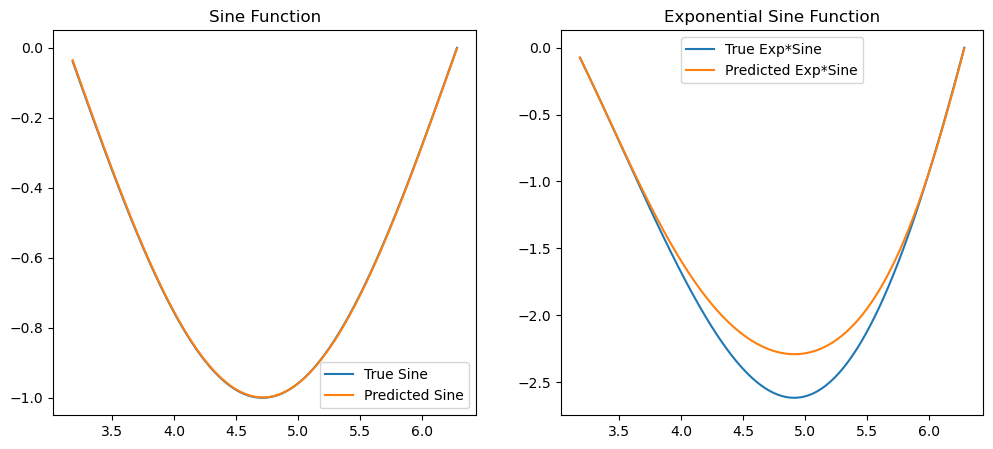

```
Sine Model Summary:
```

```
Model: "sequential_4"
```

```
┏━━━━━━━━━━━━━━━━━━━━━━━━━━━━━━━━━━━━━━┳━━━━━━━━━━━━━━━━━━━━━━━━━━━━━┳━━━━━━━━━━━━━━━━━┓
┃ Layer (type)                         ┃ Output Shape                ┃         Param # ┃
┡━━━━━━━━━━━━━━━━━━━━━━━━━━━━━━━━━━━━━━╇━━━━━━━━━━━━━━━━━━━━━━━━━━━━━╇━━━━━━━━━━━━━━━━━┩
│ lstm (LSTM)                          │ (None, 100, 50)             │          10,400 │
├──────────────────────────────────────┼─────────────────────────────┼─────────────────┤
│ lstm_1 (LSTM)                        │ (None, 50)                  │          20,200 │
├──────────────────────────────────────┼─────────────────────────────┼─────────────────┤
│ dense_38 (Dense)                     │ (None, 1)                   │              51 │
└──────────────────────────────────────┴─────────────────────────────┴─────────────────┘
```

```
 Total params: 91,955 (359.20 KB)
```

```
 Trainable params: 30,651 (119.73 KB)
```

```
 Non-trainable params: 0 (0.00 B)
```

```
 Optimizer params: 61,304 (239.47 KB)
```

```
Exponential Sine Model Summary:
```

```
Model: "sequential_5"
```

```
┏━━━━━━━━━━━━━━━━━━━━━━━━━━━━━━━━━━━━━━┳━━━━━━━━━━━━━━━━━━━━━━━━━━━━━┳━━━━━━━━━━━━━━━━━┓
┃ Layer (type)                         ┃ Output Shape                ┃         Param # ┃
┡━━━━━━━━━━━━━━━━━━━━━━━━━━━━━━━━━━━━━━╇━━━━━━━━━━━━━━━━━━━━━━━━━━━━━╇━━━━━━━━━━━━━━━━━┩
│ lstm_2 (LSTM)                        │ (None, 100, 50)             │          10,400 │
├──────────────────────────────────────┼─────────────────────────────┼─────────────────┤
│ lstm_3 (LSTM)                        │ (None, 50)                  │          20,200 │
├──────────────────────────────────────┼─────────────────────────────┼─────────────────┤
│ dense_39 (Dense)                     │ (None, 1)                   │              51 │
└──────────────────────────────────────┴─────────────────────────────┴─────────────────┘
```

```
 Total params: 91,955 (359.20 KB)
```

```
 Trainable params: 30,651 (119.73 KB)
```

```
 Non-trainable params: 0 (0.00 B)
```

```
 Optimizer params: 61,304 (239.47 KB)
```

```python
import numpy as np
import matplotlib.pyplot as plt
from tensorflow.keras.models import Sequential
from tensorflow.keras.layers import LSTM, Dense
from sklearn.preprocessing import MinMaxScaler

# Use inline backend for Jupyter
%matplotlib inline

np.random.seed(7)

# -----------------------------------------------------------------------------
# Generate data for the Sine and Exponential Sine functions
# -----------------------------------------------------------------------------
T = 8000
X_sine = np.linspace(-np.pi, np.pi, T)
Y_sine = np.sin(X_sine)

X_exp_sine = np.linspace(-6*np.pi, 1*np.pi, T)
Y_exp_sine = np.exp(0.2 * X_exp_sine) * np.sin(X_exp_sine)

# Normalize the data
scaler_sine = MinMaxScaler(feature_range=(0, 1))
Y_sine_scaled = scaler_sine.fit_transform(Y_sine.reshape(-1, 1))

scaler_exp_sine = MinMaxScaler(feature_range=(0, 1))
Y_exp_sine_scaled = scaler_exp_sine.fit_transform(Y_exp_sine.reshape(-1, 1))

# -----------------------------------------------------------------------------
# Prepare the data for LSTM
# -----------------------------------------------------------------------------
def create_sequences(data, seq_length):
    X, y = [], []
    for i in range(len(data) - seq_length):
        X.append(data[i:i + seq_length])
        y.append(data[i + seq_length])
    return np.array(X), np.array(y)

seq_length = 100
X_sine_seq, y_sine_seq = create_sequences(Y_sine_scaled, seq_length)
X_exp_sine_seq, y_exp_sine_seq = create_sequences(Y_exp_sine_scaled, seq_length)

# Reshape data to fit LSTM input shape (samples, time steps, features)
X_sine_seq = X_sine_seq.reshape((X_sine_seq.shape[0], seq_length, 1))
X_exp_sine_seq = X_exp_sine_seq.reshape((X_exp_sine_seq.shape[0], seq_length, 1))




# -----------------------------------------------------------------------------
# Build the LSTM models
# -----------------------------------------------------------------------------
# Model for Sine function
sine_model = Sequential()
sine_model.add(LSTM(50, return_sequences=True, input_shape=(seq_length, 1)))
sine_model.add(LSTM(50))
sine_model.add(Dense(1))

# Model for Exponential Sine function
exp_sine_model = Sequential()
exp_sine_model.add(LSTM(50, return_sequences=True, input_shape=(seq_length, 1)))
exp_sine_model.add(LSTM(50))
exp_sine_model.add(Dense(1))



# -----------------------------------------------------------------------------
# Compile and fit the models
# -----------------------------------------------------------------------------
sine_model.compile(optimizer='adam', loss='mse')
exp_sine_model.compile(optimizer='adam', loss='mse')

sine_model.fit(X_sine_seq, y_sine_seq, epochs=20, batch_size=64, verbose=1)
exp_sine_model.fit(X_exp_sine_seq, y_exp_sine_seq, epochs=20, batch_size=64, verbose=1)




# -----------------------------------------------------------------------------
# Generate evaluation data in the range (π, 2π) for both functions
# -----------------------------------------------------------------------------
X_eval = np.linspace(np.pi, 2*np.pi, T)
Y_sine_eval = np.sin(X_eval)
Y_exp_sine_eval = np.exp(0.2 * X_eval) * np.sin(X_eval)

# Normalize the evaluation data
Y_sine_eval_scaled = scaler_sine.transform(Y_sine_eval.reshape(-1, 1))
Y_exp_sine_eval_scaled = scaler_exp_sine.transform(Y_exp_sine_eval.reshape(-1, 1))

# Prepare sequences for evaluation
X_sine_eval_seq, _ = create_sequences(Y_sine_eval_scaled, seq_length)
X_exp_sine_eval_seq, _ = create_sequences(Y_exp_sine_eval_scaled, seq_length)

# Reshape data to fit LSTM input shape (samples, time steps, features)
X_sine_eval_seq = X_sine_eval_seq.reshape((X_sine_eval_seq.shape[0], seq_length, 1))
X_exp_sine_eval_seq = X_exp_sine_eval_seq.reshape((X_exp_sine_eval_seq.shape[0], seq_length, 1))




# Predict using the models
Y_sine_pred_scaled = sine_model.predict(X_sine_eval_seq)
Y_exp_sine_pred_scaled = exp_sine_model.predict(X_exp_sine_eval_seq)

# Inverse transform the predictions
Y_sine_pred = scaler_sine.inverse_transform(Y_sine_pred_scaled)
Y_exp_sine_pred = scaler_exp_sine.inverse_transform(Y_exp_sine_pred_scaled)



# -----------------------------------------------------------------------------
# Compare predictions vs ground truth
# -----------------------------------------------------------------------------
plt.figure(figsize=(12, 5))

# Plot Sine function predictions
plt.subplot(1, 2, 1)
plt.plot(X_eval[seq_length:], Y_sine_eval[seq_length:], label='True Sine')
plt.plot(X_eval[seq_length:], Y_sine_pred, label='Predicted Sine')
plt.title('Sine Function')
plt.legend()

# Plot Exponential Sine function predictions
plt.subplot(1, 2, 2)
plt.plot(X_eval[seq_length:], Y_exp_sine_eval[seq_length:], label='True Exp*Sine')
plt.plot(X_eval[seq_length:], Y_exp_sine_pred, label='Predicted Exp*Sine')
plt.title('Exponential Sine Function')
plt.legend()

plt.show()

# -----------------------------------------------------------------------------
# Summarize the models
# -----------------------------------------------------------------------------
print("Sine Model Summary:")
sine_model.summary()

print("\nExponential Sine Model Summary:")
exp_sine_model.summary()
```